# Week 7 · Make every transformation answer the question

MATH 346 course companion · R

**Note**

Use this chapter with the companion reading guide. **Nothing in this chapter is collected or graded.** The approved syllabus, workload guide and Blackboard remain authoritative.

## Your route

**Which observations, groups and units does this pipeline actually use?**

The main question compares observed ozone on days below 80 F with days at least 80 F. We use 153 daily New York observations from May–September 1973, then retain only days with recorded ozone and temperature for this question.

Each verb encodes a decision. We first trace simple verbs, then combine them into a two-group summary with visible denominators. The supplied AI pipeline runs but quietly substitutes a monthly comparison of warmer days.

Before you start · Words used here · Setup · Meeting 1 · Meeting 2 · AI audit · Practice and resources · Chapter list. The page contents navigation also links to the sections.

**TipA first 30-minute recovery session**

Choose a stopping point within about 30 minutes; continue from there next time. This is an untested first-pass budget, not a completion promise.

1. Check prerequisites and setup. If access is blocked, focus on that first.
2. Trace the one-verb objects and predict which operations change rows.
3. Inspect the two-group summary and reconcile its counts with retained days.
4. Try the second self-check and continue the relevant Core 3/6 checkpoint.

Read displayed results when jumping ahead; run complete code in its stated sequence when returning to your script. The full practice selection is Core **1, 3, 4, 6, 9**, selective Guided **2, 5, 8**, and optional Extension **7**, within the **90–120-minute** ordinary-week budget.

### Before you start

Use Week 6 R assignment, vectors, data frames, NA and basic ggplot syntax. The native pipe requires R 4.1 or later. No CSV import or automatic iteration is needed here. Keep a single naming scheme: this chapter follows the public scripts, including lowercase month/day and the name analysis_days.

Use [software requirements](https://lnajman.github.io/math346/resources/software-requirements.html) and the [course glossary](https://lnajman.github.io/math346/resources/glossary.html) when needed. You do not need a paid AI account or an external AI call: the flawed examples are supplied locally.

**NoteWords used in this chapter**

| Word or pattern | Meaning here |
| --- | --- |
| **Pipe `\\|>`** | Pass the object on the left into the next operation. |
| **Verb** | A data operation such as select, filter or mutate. |
| **Invariant** | A property expected to remain true at a stage. |
| **Logical selector** | TRUE/FALSE values deciding which rows are retained. |
| **Derived variable** | A new value calculated from fields, such as Celsius. |
| **Group** | Rows sharing the comparison label used by the next operation. |
| **Denominator** | The count of observations contributing to a group summary. |
| **Descriptive comparison** | A statement about observed groups, without a causal claim. |

### Read / Explain / Check / Interpret

Read the inputs and operations; explain your prediction; check a specific claim; interpret the result with its domain or units.

Think first; write a private comment only where requested—see the prediction guide.

## Setup

Use the dplyr and ggplot2 packages and built-in airquality data. Save both starters in a `week07` folder; no file import is required.

Download the starters first. Keep these files in your working folder: `week07-verb-checks.R`; `week07-dplyr-eda.R`.

Possible solutions are separate comparison files linked below.

- Starter: week07-verb-checks.R
- Starter: week07-dplyr-eda.R
- AI critique target: week07-ai-pipeline-review.R

Run this before the other blocks; it reports missing paths without changing files.

```r
required_paths <- c("week07-verb-checks.R", "week07-dplyr-eda.R")
```

```r
missing_paths <- required_paths[!file.exists(required_paths)]
if (length(missing_paths) == 0) {
  cat("Setup OK\n")
} else {
  cat("Missing from the current folder:\n", paste(missing_paths, collapse = "\n"), "\n", sep = "")
}
```

**Example output when all required files are present:**

```
Setup OK
```

This is example output, not confirmation of your computer’s setup. Run the check in your own R session and read that result. Restart R, then run the chapter’s code in order, including the code inside the reference reveals. A successful `stopifnot` is silent; a failed condition stops the script.

## Meeting 1 · Read the computation

Class route: two 75-minute meetings, each with its final five-minute exit.

`select` keeps columns; `filter` keeps rows where its conditions are TRUE; `mutate` adds or changes columns; `arrange` changes order. Predict the input and output object for every line. A count that should remain unchanged is an invariant, while a legitimate filter needs explicit retained/excluded counts.

### Read one verb at a time

**Slide cues:** *Rename With Units*; *`select`: Keep Variables*; *`filter`: Keep Rows*; *`mutate`: Create Variables*; *`arrange`: Change Order*.

The script starts with six columns and 153 rows. Renaming carries units into ozone_ppb, wind_mph and temp_f without changing observations. select keeps five columns, then the warm-day filter retains 73 rows because temperature is complete. It has not required ozone to be observed.

The Celsius formula applies to every retained temperature. Arrange sorts observed ozone descending and leaves missing ozone to be handled separately. In the final check the missing values are omitted only for checking the order of observed values; this is not a claim that the data are complete.

**Predict in a private comment first:** Which of select, filter, mutate and arrange can change the number of rows in this script? Does arranging ozone remove its missing values?

**Compare your reasoning**

Only filter changes the row count here. Select changes columns, mutate adds Celsius, and arrange changes order. Missing ozone remains present after sorting. If your answer differed, distinguish changing row order from removing rows and changing the set of variables from changing observations.

**Try before expanding:** Use Core 1/3/4 to trace object dimensions and complete a known-temperature check before comparing the reference.

**Reference version · week07-verb-checks_sol.R**

```r
# MATH 346 - possible worked solution
# Compare only after attempting the starter; other correct implementations are possible.

# MATH 346 - Week 7
# One transformation verb at a time, with a check after every step

library(dplyr)
air <- airquality |>
  as_tibble() |>
  rename(
    ozone_ppb = Ozone,
    wind_mph = Wind,
    temp_f = Temp,
    month = Month,
    day = Day
  )

selected <- air |>
  select(month, day, ozone_ppb, temp_f, wind_mph)

warm_days <- selected |>
  filter(temp_f >= 80)

with_celsius <- warm_days |>
  mutate(temp_c = (temp_f - 32) * 5 / 9)

ordered_ozone <- with_celsius |>
  arrange(desc(ozone_ppb))

warm_month_counts <- with_celsius |>
  count(month, name = "n_warm_days") |>
  arrange(month)

stopifnot(
  nrow(selected) == nrow(air),
  identical(names(selected), c("month", "day", "ozone_ppb", "temp_f", "wind_mph")),
  nrow(warm_days) <= nrow(selected),
  nrow(warm_days) == 73,
  nrow(with_celsius) == nrow(warm_days),
  "temp_c" %in% names(with_celsius),
  all(abs(with_celsius$temp_c - (with_celsius$temp_f - 32) * 5 / 9) < 1e-12),
  sum(warm_month_counts$n_warm_days) == nrow(warm_days),
  all(diff(ordered_ozone$ozone_ppb[!is.na(ordered_ozone$ozone_ppb)]) <= 0)
)

print(warm_month_counts)
```

```
# A tibble: 5 × 2
  month n_warm_days
  <int>       <int>
1     5           1
2     6          12
3     7          29
4     8          21
5     9          10
```

```r
cat("select: rows preserved =", nrow(selected), "\n")
```

```
select: rows preserved = 153
```

```r
cat("filter: warm rows retained =", nrow(warm_days), "\n")
```

```
filter: warm rows retained = 73
```

```r
cat("mutate: Celsius variable checked for every retained row.\n")
```

```
mutate: Celsius variable checked for every retained row.
```

```r
cat("arrange: observed ozone values are in descending order.\n")
```

```
arrange: observed ozone values are in descending order.
```

```r
cat("All one-verb checks passed.\n")
```

```
All one-verb checks passed.
```

**Explain / Check / Interpret:** The source checks 73 warm days and preserves that count through mutate; monthly warm counts account for those rows. Known values 32 F → 0 C and 212 F → 100 C independently check the conversion formula. A formula compared with itself tests implementation consistency but is weaker than those known answers. Keep the original airquality object available.

### Meeting 1 in-class exit · Final five minutes

For `select`, `filter`, `mutate`, and `arrange`:

1. what changes?
2. what should remain invariant?

Solo readers: use the self-check below; no submission.

### Meeting 1 self-check · No submission

For the verb/invariant activity: select removes Solar.R and then mutate adds Celsius. What should happen to the day count, and why is that a useful expectation?

**Compare the Meeting 1 self-check**

Both preserve the day rows in this workflow. A row-count check would expose an unintended row filter, but would not verify the Celsius formula or identify substituted observations. Match different checks to different promises.

## Meeting 2 · Check the claim

The one-verb example keeps all warm days, including days with missing ozone. The full comparison instead filters required measurements before creating two temperature groups. These are different intermediate populations, so do not transplant the 73 warm-row expectation into the 116-day complete-observation workflow. Missingness handling is tied to the question.

### Reduce days to a two-group comparison

**Slide cues:** *`group_by`: Define Units Of Comparison*; *`summarize`: Reduce Rows*; *Keep The Denominator*; *Validate The Reduction*.

The explicit missing-value filter removes 37 days without ozone and none for temperature, leaving 116 usable days. Only variables required for this question determine that rule: dropping every row missing Solar.R would change the population unnecessarily.

`if_else(temp_f >= 80, ...)` assigns the exact threshold to the warmer group. The factor levels order the two displayed labels. group_by does not itself reduce rows; summarize returns one row per band with its count, mean and median. The separate monthly summary uses the same usable days but answers another question. `.groups = "drop"` removes grouping metadata afterward.

**Predict · Think first:** Do the two temperature-group counts need to sum to 153 or 116? Can the unweighted mean of the two group means replace the overall day-level mean?

**Compare your reasoning**

They sum to 116 usable days: 59 cooler and 57 warmer. The overall mean weights each group by its count; an unweighted mean gives unequal-sized groups equal influence. If your answer differed, use the row population at the summary stage and keep its denominator beside every mean.

**Try before expanding:** Complete Core 6 with an explicit two-label grouping rule and counts before expanding. Check that equality belongs in the >= 80 group.

**Reference version · week07-dplyr-eda_sol.R**

```r
# MATH 346 - possible worked solution
# Compare only after attempting the starter; other correct implementations are possible.

# MATH 346 - Week 7
# Data transformation as question-answering with dplyr

library(dplyr)
library(ggplot2)

# Daily New York air-quality measurements, May-September 1973.
air <- airquality |>
  as_tibble() |>
  rename(
    ozone_ppb = Ozone,
    solar_radiation_langleys = Solar.R,
    wind_mph = Wind,
    temp_f = Temp,
    month = Month,
    day = Day
  )

missing_audit <- air |>
  summarize(
    rows = n(),
    missing_ozone = sum(is.na(ozone_ppb)),
    missing_temperature = sum(is.na(temp_f))
  )

print(missing_audit)
```

```
# A tibble: 1 × 3
   rows missing_ozone missing_temperature
  <int>         <int>               <int>
1   153            37                   0
```

```r
# Question: How does observed ozone differ between cooler and warmer days?
# Only rows with both variables observed can answer this question.
analysis_days <- air |>
  filter(!is.na(ozone_ppb), !is.na(temp_f)) |>
  mutate(
    temp_c = (temp_f - 32) * 5 / 9,
    temperature_band = if_else(
      temp_f >= 80,
      "80 F or warmer",
      "below 80 F"
    ),
    temperature_band = factor(
      temperature_band,
      levels = c("below 80 F", "80 F or warmer")
    )
  ) |>
  select(
    month, day, ozone_ppb, temp_f, temp_c, wind_mph, temperature_band
  )

temperature_summary <- analysis_days |>
  group_by(temperature_band) |>
  summarize(
    n_days = n(),
    mean_ozone_ppb = mean(ozone_ppb),
    median_ozone_ppb = median(ozone_ppb),
    .groups = "drop"
  )

monthly_summary <- analysis_days |>
  group_by(month) |>
  summarize(
    n_days = n(),
    mean_ozone_ppb = mean(ozone_ppb),
    .groups = "drop"
  ) |>
  arrange(month)

print(temperature_summary)
```

```
# A tibble: 2 × 4
  temperature_band n_days mean_ozone_ppb median_ozone_ppb
  <fct>             <int>          <dbl>            <int>
1 below 80 F           59           22.6               20
2 80 F or warmer       57           62.4               63
```

```r
print(monthly_summary)
```

```
# A tibble: 5 × 3
  month n_days mean_ozone_ppb
  <int>  <int>          <dbl>
1     5     26           23.6
2     6      9           29.4
3     7     26           59.1
4     8     26           60.0
5     9     29           31.4
```

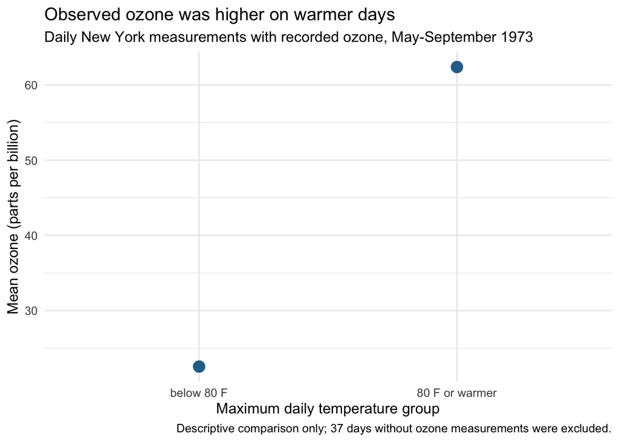

```r
stopifnot(
  nrow(air) == 153,
  missing_audit$missing_ozone == 37,
  missing_audit$missing_temperature == 0,
  nrow(analysis_days) == 116,
  sum(temperature_summary$n_days) == nrow(analysis_days),
  sum(monthly_summary$n_days) == nrow(analysis_days),
  nrow(temperature_summary) == 2,
  nrow(monthly_summary) == 5,
  !anyNA(temperature_summary),
  all(abs(analysis_days$temp_c - (analysis_days$temp_f - 32) * 5 / 9) < 1e-12)
)

summary_plot <- ggplot(
  temperature_summary,
  aes(x = temperature_band, y = mean_ozone_ppb)
) +
  geom_point(size = 4, color = "#2A6F97") +
  labs(
    title = "Observed ozone was higher on warmer days",
    subtitle = "Daily New York measurements with recorded ozone, May-September 1973",
    x = "Maximum daily temperature group",
    y = "Mean ozone (parts per billion)",
    caption = "Descriptive comparison only; 37 days without ozone measurements were excluded."
  ) +
  theme_minimal(base_size = 12)

plot_data <- ggplot_build(summary_plot)$data[[1]]
stopifnot(nrow(plot_data) == nrow(temperature_summary))

print(summary_plot)
```

```r
cat("Rows retained for the question:", nrow(analysis_days), "of", nrow(air), "\n")
```

```
Rows retained for the question: 116 of 153
```

```r
cat("All Week 7 transformation checks passed.\n")
```

```
All Week 7 transformation checks passed.
```

**Explain / Check / Interpret:** The checked means are about 22.6 ppb below 80 F and 62.4 ppb at or above 80 F. Describe the difference for these observations with units and the 37 excluded days. Reconciliation shows the computation accounted for usable rows; it does not establish representativeness or explain why ozone was missing.

## AI audit · Inspect before accepting

**Slide cues:** *Plausible AI Pipeline*; *Locate The Question Drift*; *Repair Pattern*.

This section supports **Core 9**. Use its code-reading and checking steps for that exercise. The full AI-review lab is used only when selected.

Read the supplied target and choose a check before opening the diagnosis. No AI service is contacted.

Candidate checks: both temperature groups retained; intended group labels; raw/usable/excluded accounting; group counts; units. Trace filter and group_by in the supplied example before looking at its final printed diagnosis.

**Reading excerpt:** this fragment relies on the supplied script setup; inspect it here, then run the complete file in the evidence reveal.

```r
ai_pipeline <- airquality |>
  as_tibble() |>
  filter(Temp >= 80, !is.na(Ozone)) |>
  group_by(Month) |>
  summarize(
    n_days = n(),
    mean_ozone = mean(Ozone),
    .groups = "drop"
  )
```

**Predict in a private comment first:** What question does the generated code answer, and why can its 57-day total be numerically correct while failing the requested comparison?

**Compare your reasoning**

It summarizes recorded ozone by month among warmer days only. The 57 days are a legitimate subset, but cooler days were removed and Month replaces the requested temperature grouping. Repair the population/grouping choices, then recheck both counts. If your answer differed, execution and plausible means may have distracted you from translating each verb back to the question.

**Run the complete supplied critique target and inspect the evidence**

```r
# MATH 346 - Week 7
# AI pipeline critique starter
#
# Prompt: "Compare observed ozone on cooler and warmer days."
# The generated code runs, but it answers a different question.

library(dplyr)

ai_pipeline <- airquality |>
  as_tibble() |>
  filter(Temp >= 80, !is.na(Ozone)) |>
  group_by(Month) |>
  summarize(
    n_days = n(),
    mean_ozone = mean(Ozone),
    .groups = "drop"
  )

print(ai_pipeline)
```

```
# A tibble: 5 × 3
  Month n_days mean_ozone
  <int>  <int>      <dbl>
1     5      1       45
2     6      4       40.5
3     7     24       63.0
4     8     18       72.5
5     9     10       53.3
```

```r
stopifnot(
  nrow(ai_pipeline) > 0,
  !anyNA(ai_pipeline),
  sum(ai_pipeline$n_days) == 57
)

cat("The generated pipeline runs and produces plausible numbers.\n")
```

```
The generated pipeline runs and produces plausible numbers.
```

```r
cat("It keeps only warmer days and groups by month, so it cannot compare cooler and warmer days.\n")
```

```
It keeps only warmer days and groups by month, so it cannot compare cooler and warmer days.
```

```r
# Review questions:
# 1. Which rows were removed before any comparison was made?
# 2. Is Month the grouping variable requested by the prompt?
# 3. What derived variable would represent the two requested groups?
# 4. How many rows have missing ozone, and where should that be documented?
# 5. Which counts should add back to the number of usable rows?
```

Use the existing AI policy when assistance is used: explain every accepted line and keep the requested evidence with your existing work. A passing test never replaces checking whether the code answers the actual question.

### Meeting 2 in-class exit · Final five minutes

A trustworthy transformation pipeline must make visible …

Solo readers: use the self-check below; no submission.

### Meeting 2 self-check · No submission

Close earlier reveals and explain from memory: A pipeline retains 116 usable days but groups by month. Its five group counts sum to 116. Does this establish that it answers the cooler-versus-warmer question?

**Compare the Meeting 2 self-check**

No. Accounting can pass for the wrong grouping. One result row now means one month rather than one temperature band. Create the two-band variable and check intended labels, row meaning and denominators as well as total counts.

## Practice, recovery and resources

**Core:** 1, 3, 4, 6, 9. **Guided:** 2, 5, 8. **Extension:** 7.

Core 1 reads a pipeline; Core 3 accounts for selected/usable rows; Core 4 checks the conversion; Core 6 compares groups; Core 9 audits question drift. Monthly summaries remain Guided 8 and changing thresholds remains Extension 7.

Attempt the selected starter blocks before comparing possible solutions. TODO comments are placeholders, not completed analysis. Keep your checked script and follow Blackboard if a checkpoint is requested.

**If you are stuck:** inspect retained rows, group labels, summary denominators, and units. Run missing definitions before their first use. Keep the first error and ask for help if a focused attempt remains blocked.

- Possible solution: week07-verb-checks_sol.R
- Possible solution: week07-dplyr-eda_sol.R

**Where this fits:** [Week 7 notes](https://lnajman.github.io/math346/weeks/week-07.html) · [Matching slides](https://lnajman.github.io/math346/slides/week-07.html) · [Main lab](https://lnajman.github.io/math346/labs/lab-07-data-transformation.html) · [AI-review lab](https://lnajman.github.io/math346/labs/lab-07-ai-pipeline-review.html) · [Exercises](https://lnajman.github.io/math346/weeks/week-07-exercises.html).